# Эффективность Ангиодина (?)

A. G.

Feb 11, 2018

# Анализ ассоциаций

## Ассоциация FWF ~ FBs

Насколько FWF (Ангиодин) соответсвует “золотому стандарту” FBs (биопсия) в определении стадии фиброза?

### Таблица сопряженности (FWF в строках и FBs в столбцах)

|  | 0 | 1 | 2 | 3 | 4 |
| --- | --- | --- | --- | --- | --- |
| 0 | 37 | 9 | 2 | 0 | 0 |
| 1 | 2 | 13 | 2 | 0 | 0 |
| 2 | 2 | 0 | 13 | 1 | 0 |
| 3 | 0 | 0 | 1 | 7 | 0 |
| 4 | 2 | 1 | 0 | 1 | 16 |

### Точный тест Фишера

```
##
##  Fisher's Exact Test for Count Data with simulated p-value (based
##  on 10000 replicates)
##
## data:  table(df$FWF, df$FBs)
## p-value = 9.999e-05
## alternative hypothesis: two.sided
```

Поскольку p-уровень значимости (p-value) значительно ниже 0.01, мы можем отвергнуть нулевую гипотезу о независимости FWF и FBs

### График сопряженности FWF и FBs

На графике видны отклонения ожидаемых частот от наблюдаемых величин. Высота прямоугольника показывает абсолютную величину этого отклонения, а положение — знак отклонения. Отчетливо видно, что для всех стадий FWF характерна та же стадия, определенная по FBs.

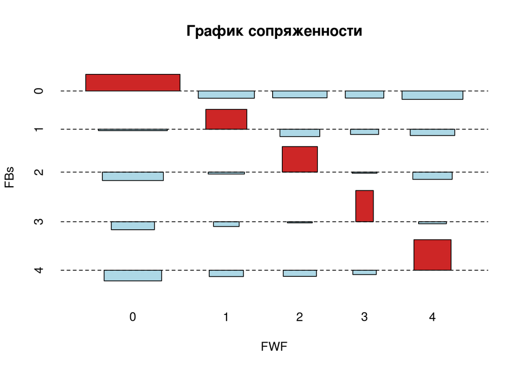

### Тест Крамера на силу ассоциации двух факторов

```
##                     X^2 df P(> X^2)
## Likelihood Ratio 182.87 16        0
## Pearson          249.77 16        0
##
## Phi-Coefficient   : NA
## Contingency Coeff.: 0.834
## Cramer's V        : 0.757
```

Тест Крамера показывает, что уровень ассоциации равен 0.7568831. Это означает, что связь сильная.

## Ассоциация SWS ~ SBs

Насколько SWS (Ангиодин) соответсвует “золотому стандарту” SBs (биопсия) в определении стадии стеатоза?

### Таблица сопряженности (в строках SWS, в столбцах SBs)

|  | 0 | 1 | 2 | 3 |
| --- | --- | --- | --- | --- |
| 0 | 43 | 6 | 0 | 0 |
| 1 | 4 | 16 | 1 | 0 |
| 2 | 0 | 2 | 11 | 1 |
| 3 | 3 | 3 | 13 | 6 |

### Точный тест Фишера

```
##
##  Fisher's Exact Test for Count Data with simulated p-value (based
##  on 10000 replicates)
##
## data:  table(df$SWS, df$SBs)
## p-value = 9.999e-05
## alternative hypothesis: two.sided
```

Поскольку p-уровень значимости (p-value) значительно ниже 0.01, мы можем отвергнуть нулевую гипотезу о независимости SWS и SBs

### График сопряженности SWS и SBs

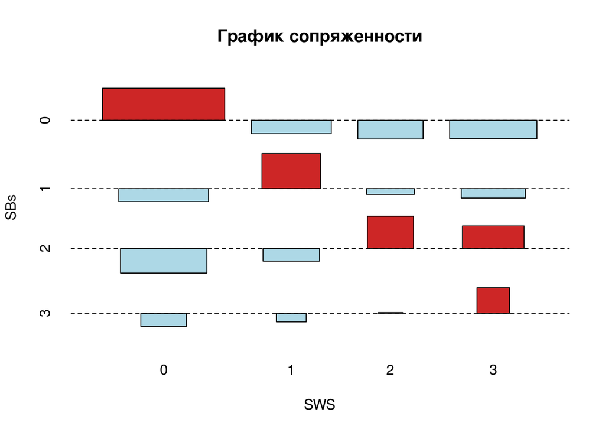

### Тест Крамера на силу ассоциации двух факторов

```
##                     X^2 df P(> X^2)
## Likelihood Ratio 122.92  9        0
## Pearson          121.39  9        0
##
## Phi-Coefficient   : NA
## Contingency Coeff.: 0.726
## Cramer's V        : 0.609
```

Тест Крамера показывает, что уровень ассоциации равен 0.6092878. Это означает, что связь между SBs и SWS средняя.

## Ассоциация FScan ~ FBs

### Таблица сопряженности (Fscan в строках, FBs в столбцах)

|  | 0 | 1 | 2 | 3 | 4 |
| --- | --- | --- | --- | --- | --- |
| 0 | 34 | 9 | 2 | 0 | 0 |
| 1 | 3 | 10 | 1 | 1 | 0 |
| 2 | 2 | 1 | 9 | 0 | 0 |
| 3 | 4 | 1 | 4 | 6 | 0 |
| 4 | 0 | 2 | 2 | 2 | 16 |

### Тест Фишера

```
##
##  Fisher's Exact Test for Count Data with simulated p-value (based
##  on 10000 replicates)
##
## data:  table(df$Fscan, df$FBs)
## p-value = 9.999e-05
## alternative hypothesis: two.sided
```

### График сопряженности

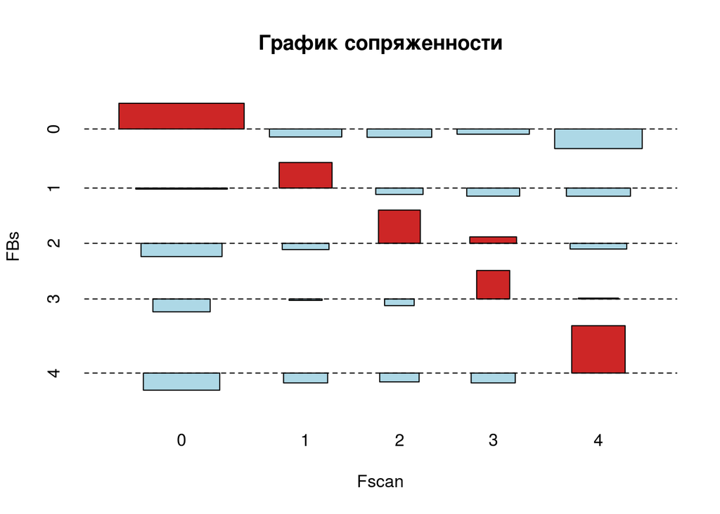

### Тест Крамера на силу ассоциации

```
##                     X^2 df P(> X^2)
## Likelihood Ratio 139.77 16        0
## Pearson          163.61 16        0
##
## Phi-Coefficient   : NA
## Contingency Coeff.: 0.775
## Cramer's V        : 0.613
```

## Ассоциация FWF ~ SBs

### Таблица сопряженности (FWF в строках, SBs в столбцах)

|  | 0 | 1 | 2 | 3 |
| --- | --- | --- | --- | --- |
| 0 | 16 | 11 | 18 | 3 |
| 1 | 9 | 6 | 2 | 0 |
| 2 | 10 | 4 | 1 | 1 |
| 3 | 6 | 2 | 0 | 0 |
| 4 | 9 | 4 | 4 | 3 |

### Тест Фишера

```
##
##  Fisher's Exact Test for Count Data with simulated p-value (based
##  on 10000 replicates)
##
## data:  table(df$FWF, df$SBs)
## p-value = 0.1136
## alternative hypothesis: two.sided
```

p-уровень значимости выше 0.05, поэтому мы не можем отвергнуть нулевую гипотезу о независимости FWF и SBs.

## Ассоциация FScan ~ FWF

### Таблица сопряженности (Fscan в строках, FWF в столбцах)

```
##
##      0  1  2  3  4
##   0 38  5  0  0  2
##   1  6  7  1  1  0
##   2  2  3  6  1  0
##   3  2  1  7  5  0
##   4  0  1  2  1 18
```

### Тест Фишера

```
##
##  Fisher's Exact Test for Count Data with simulated p-value (based
##  on 10000 replicates)
##
## data:  table(df$FWF, df$Fscan)
## p-value = 9.999e-05
## alternative hypothesis: two.sided
```

p-уровень значимости значительно ниже 0.01, поэтому мы отвергаем нулевую гипотезу о независимости FScan и FWF

### График сопряженности

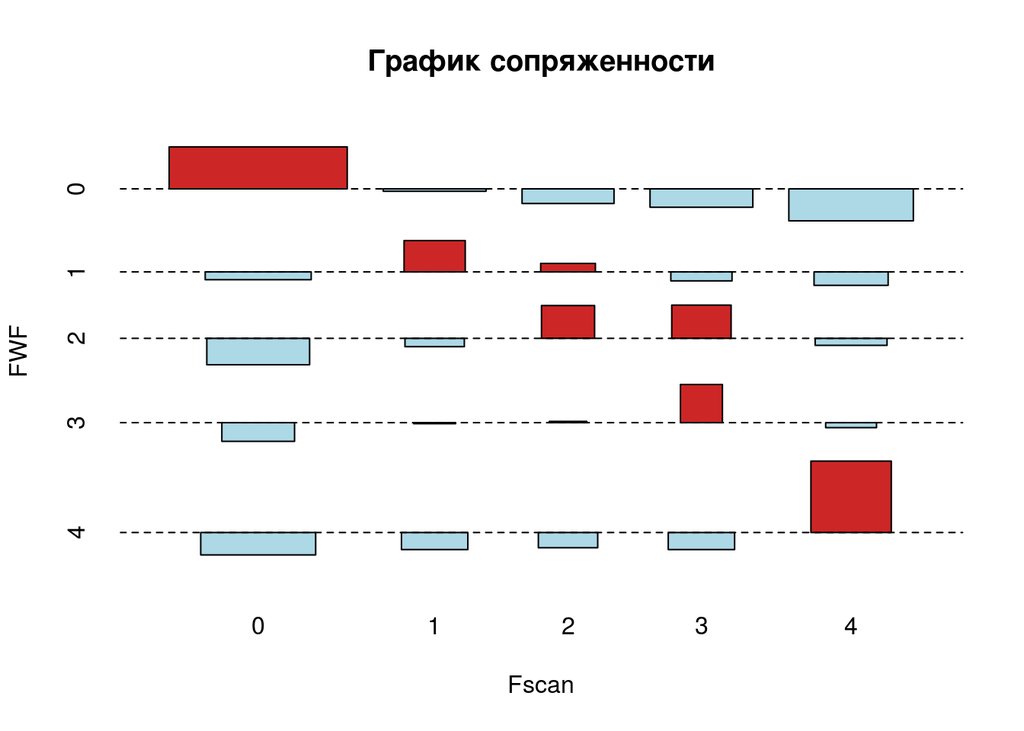

### Тест Крамера на силу ассоциации

```
##                     X^2 df P(> X^2)
## Likelihood Ratio 140.07 16        0
## Pearson          151.22 16        0
##
## Phi-Coefficient   : NA
## Contingency Coeff.: 0.762
## Cramer's V        : 0.589
```

Сила ассоциации средняя (V=0.5889266)

## Ассоциация SBs и Fscan

### Таблица сопряженности (SBs в строках, Fscan в столбцах)

```
##
##      0  1  2  3  4
##   0 14 10  4 11 11
##   1 10  3  5  4  5
##   2 19  1  2  0  3
##   3  2  1  1  0  3
```

### Тест Фишера

```
##
##  Fisher's Exact Test for Count Data with simulated p-value (based
##  on 10000 replicates)
##
## data:  table(df$SBs, df$Fscan)
## p-value = 0.009299
## alternative hypothesis: two.sided
```

### График сопряженности

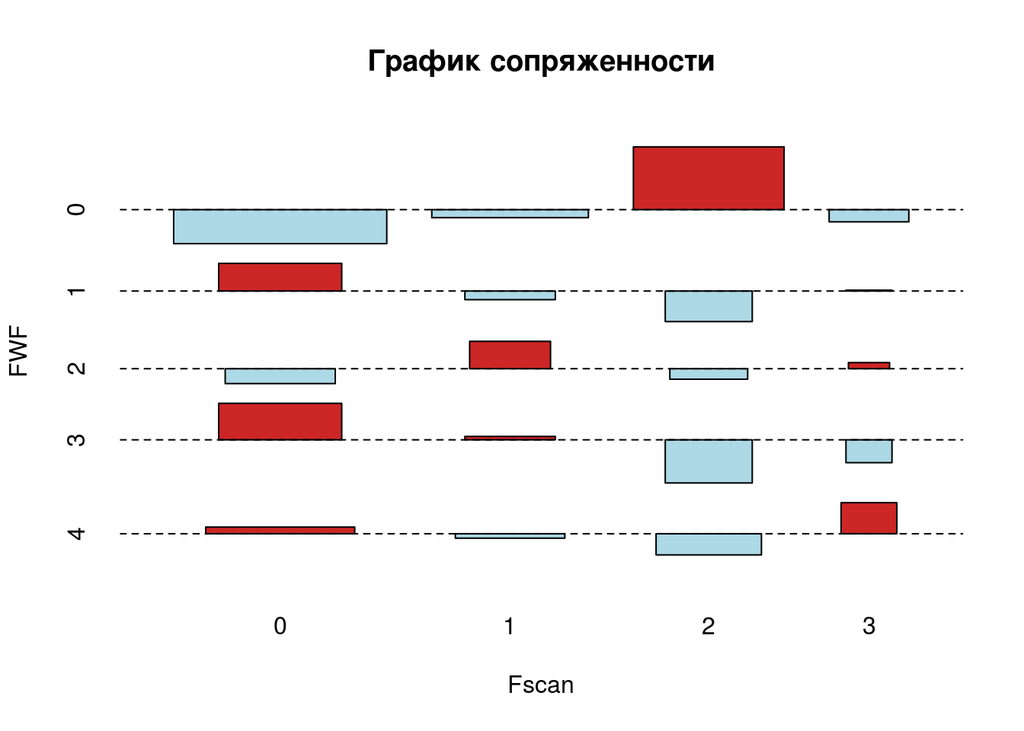

### Тест Крамера на силу ассоциации

```
##                     X^2 df  P(> X^2)
## Likelihood Ratio 27.706 12 0.0061059
## Pearson          24.803 12 0.0157867
##
## Phi-Coefficient   : NA
## Contingency Coeff.: 0.431
## Cramer's V        : 0.275
```

Сила ассоциации малая (V=0.2754067)

# Регрессионный анализ

## Биномиальная логистическая регрессия

### Определение 0 и 1 стадий фиброза (FBs - FWF)

#### Модель: FBs ~ FWF

Предикторы, кроме FWF0, статистически незначимы!

```
##
## Call:
## glm(formula = FWF.true ~ FWF, family = "binomial", data = df.F01)
##
## Deviance Residuals:
##     Min       1Q   Median       3Q      Max
## -2.0074   0.5350   0.6599   0.6599   0.6599
##
## Coefficients:
##              Estimate Std. Error z value Pr(>|z|)
## (Intercept)    1.4137     0.3717   3.804 0.000143 ***
## FWF1           0.4581     0.8456   0.542 0.587992
## FWF2         -18.9798  2797.4420  -0.007 0.994587
## FWF4         -18.9798  2284.1018  -0.008 0.993370
## ---
## Signif. codes:  0 '***' 0.001 '**' 0.01 '*' 0.05 '.' 0.1 ' ' 1
##
## (Dispersion parameter for binomial family taken to be 1)
##
##     Null deviance: 73.109  on 65  degrees of freedom
## Residual deviance: 57.257  on 62  degrees of freedom
## AIC: 65.257
##
## Number of Fisher Scoring iterations: 16
```

#### ROC-кривая

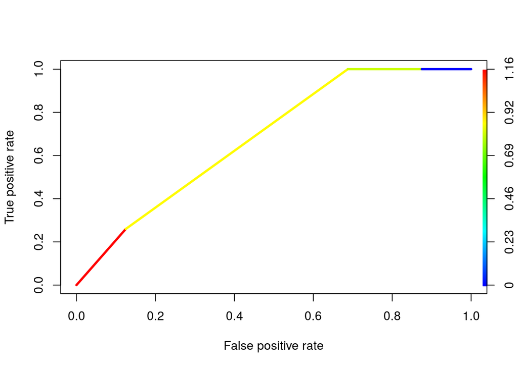

Площадь под кривой AUC=0.683125

#### Кривые специфичности, чувствительности и аккуратности модели

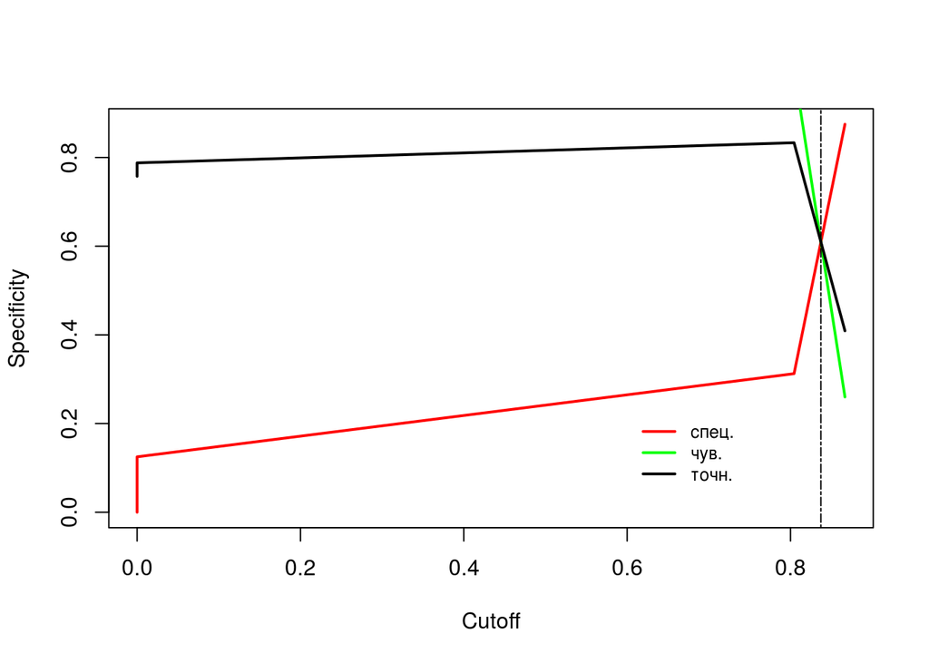

#### Аккуратность, чувствительность и специфичность выбранной модели

- Доля правильно классифицированных случаев PCCC = 0.8015539
- Чувствительность модели Se = 0.3125
- Специфичность модели Sp = 1

### Определение 2 и 3 стадий (FWF ~ FBs)

#### Модель: FBs ~ FWF

Предикторы статистически незначимы!

```
##
## Call:
## glm(formula = FWF.true ~ FWF, family = "binomial", data = df.F23)
##
## Deviance Residuals:
##     Min       1Q   Median       3Q      Max
## -2.2974   0.1925   0.3850   0.4509   0.5168
##
## Coefficients:
##               Estimate Std. Error z value Pr(>|z|)
## (Intercept) -1.957e+01  7.604e+03  -0.003    0.998
## FWF1         2.470e-09  1.075e+04   0.000    1.000
## FWF2         2.213e+01  7.604e+03   0.003    0.998
## FWF3         2.151e+01  7.604e+03   0.003    0.998
## FWF4         2.457e-09  1.317e+04   0.000    1.000
##
## (Dispersion parameter for binomial family taken to be 1)
##
##     Null deviance: 30.903  on 26  degrees of freedom
## Residual deviance: 13.233  on 22  degrees of freedom
## AIC: 23.233
##
## Number of Fisher Scoring iterations: 18
```

#### ROC-кривая

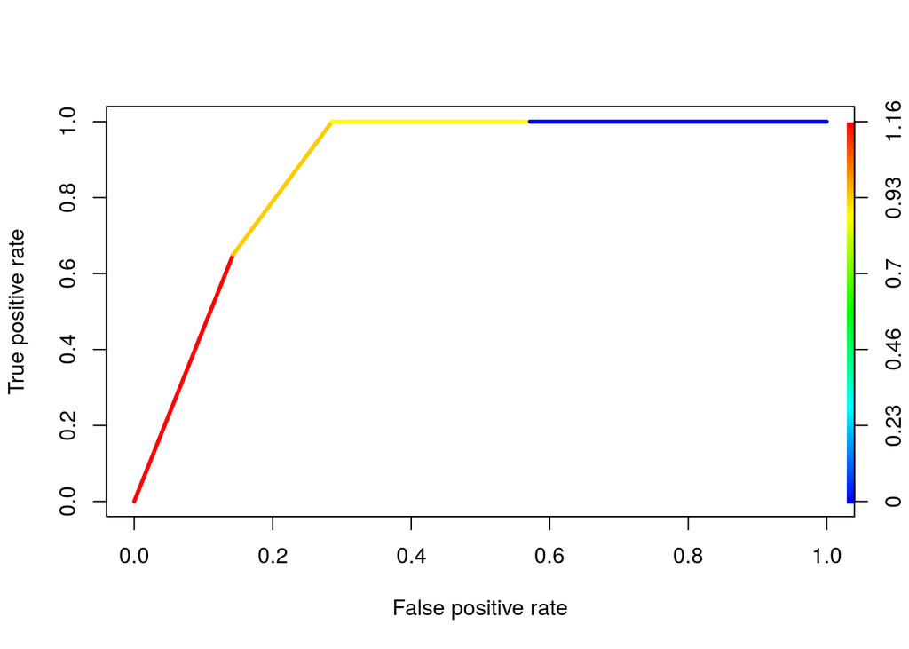

Площадь под кривой AUC=0.8785714

#### Кривые специфичности, чувствительности и аккуратности модели

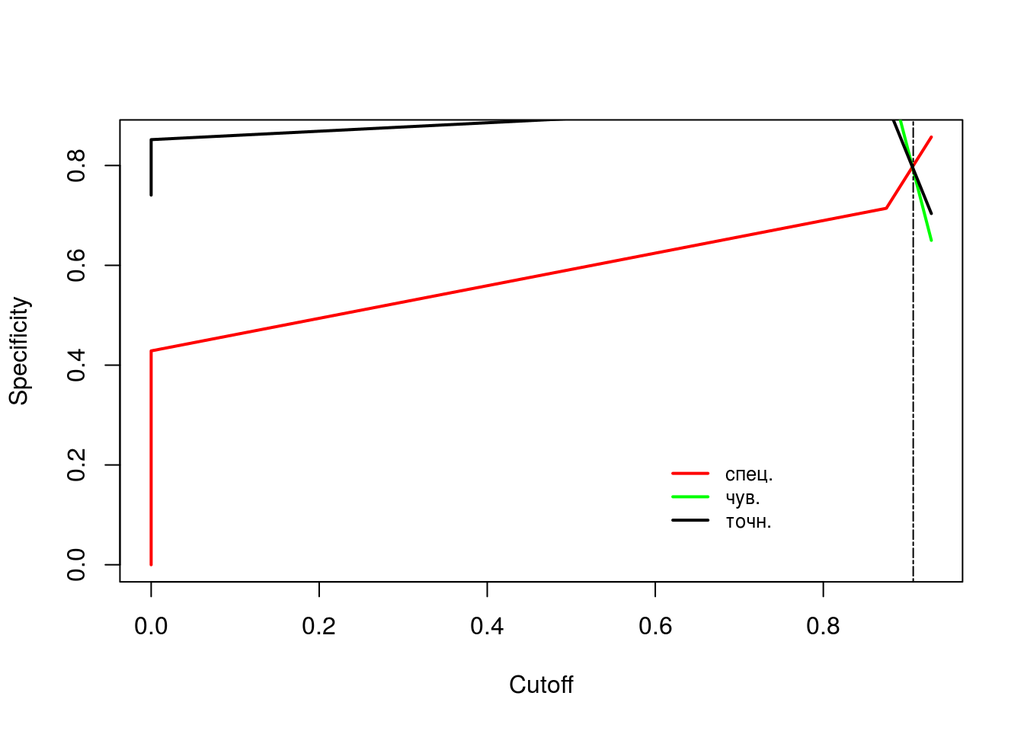

#### Аккуратность, чувствительность и специфичность выбранной модели

- Доля правильно классифицированных случаев PCCC = 0.9000101
- Чувствительность модели Se = 0.7142857
- Специфичность модели Sp = 1

### Определение 4 стадии (FWF ~ FBs)

В данном случае мы имеем 100% совпадение показателей FWF и FBs

|  | FWF | FBs |
| --- | --- | --- |
| 3 | 4 | 4 |
| 4 | 4 | 4 |
| 5 | 4 | 4 |
| 6 | 4 | 4 |
| 23 | 4 | 4 |
| 55 | 4 | 4 |
| 57 | 4 | 4 |
| 58 | 4 | 4 |
| 101 | 4 | 4 |
| 102 | 4 | 4 |
| 103 | 4 | 4 |
| 104 | 4 | 4 |
| 105 | 4 | 4 |
| 106 | 4 | 4 |
| 107 | 4 | 4 |
| 109 | 4 | 4 |

### Определение 0 стадии стеатоза (SBs - SWS)

#### Модель: SBs ~ SWS

Предикторы статистически незначимы!

```
##
## Call:
## glm(formula = SBs.true ~ SWS, family = "binomial", data = df.S0)
##
## Deviance Residuals:
##        Min          1Q      Median          3Q         Max
## -2.409e-06   2.409e-06   2.409e-06   2.409e-06   2.409e-06
##
## Coefficients:
##              Estimate Std. Error z value Pr(>|z|)
## (Intercept)     26.57   54308.41       0        1
## SWS1           -53.13  186159.82       0        1
## SWS3           -53.13  212659.75       0        1
##
## (Dispersion parameter for binomial family taken to be 1)
##
##     Null deviance: 4.0496e+01  on 49  degrees of freedom
## Residual deviance: 2.9008e-10  on 47  degrees of freedom
## AIC: 6
##
## Number of Fisher Scoring iterations: 25
```

#### ROC-кривая

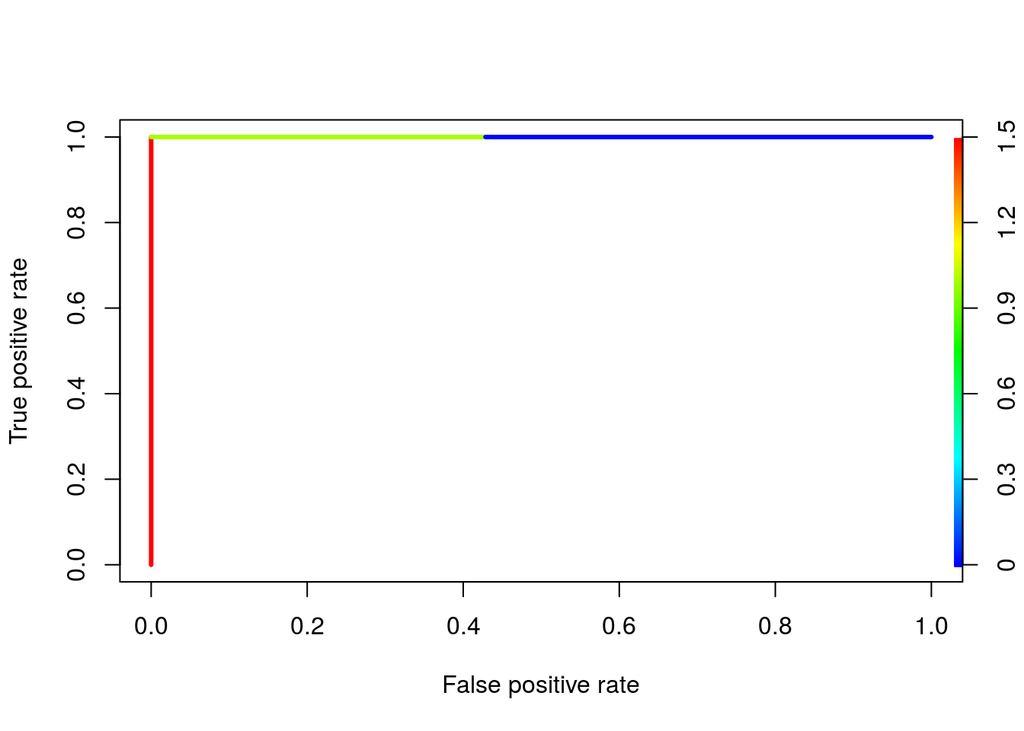

Площадь под кривой AUC=1

#### Кривые специфичности, чувствительности и аккуратности модели

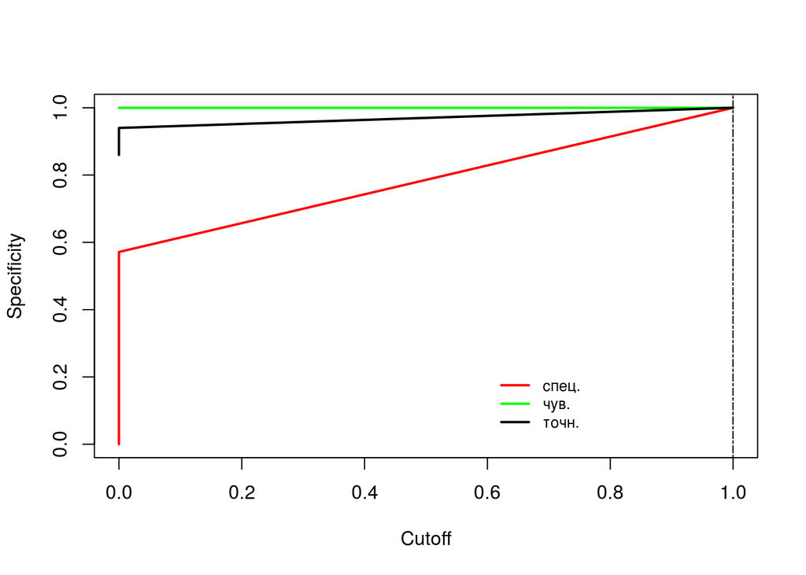

#### Аккуратность, чувствительность и специфичность выбранной модели

- Доля правильно классифицированных случаев PCCC = 0.9872269
- Чувствительность модели Se = 1
- Специфичность модели Sp = 1

### Определение 1 стадии стеатоза (SBs ~ SWS)

#### Модель: SBs ~ SWS

Предикторы статистически незначимы!

```
##
## Call:
## glm(formula = SBs.true ~ SWS, family = "binomial", data = df.S1)
##
## Deviance Residuals:
##        Min          1Q      Median          3Q         Max
## -3.971e-06  -3.971e-06   3.971e-06   3.971e-06   3.971e-06
##
## Coefficients:
##               Estimate Std. Error z value Pr(>|z|)
## (Intercept) -2.557e+01  8.818e+04       0        1
## SWS1         5.113e+01  1.034e+05       0        1
## SWS2        -4.065e-30  1.764e+05       0        1
## SWS3        -7.934e-14  1.527e+05       0        1
##
## (Dispersion parameter for binomial family taken to be 1)
##
##     Null deviance: 3.6499e+01  on 26  degrees of freedom
## Residual deviance: 4.2579e-10  on 23  degrees of freedom
## AIC: 8
##
## Number of Fisher Scoring iterations: 24
```

#### ROC-кривая

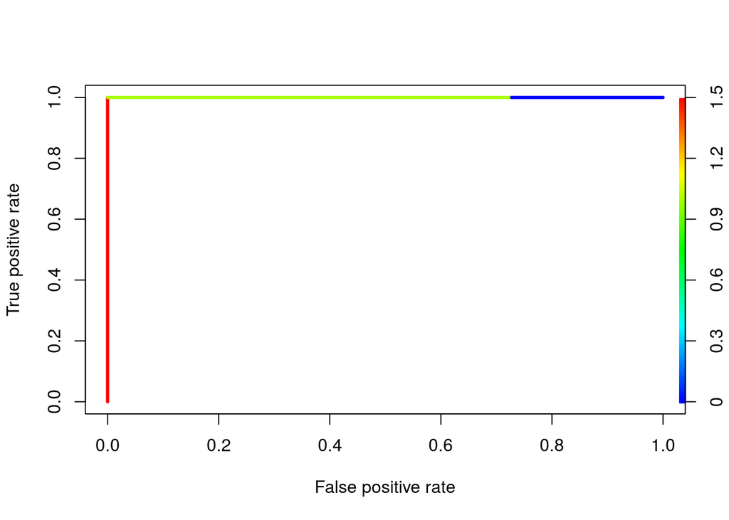

Площадь под кривой AUC=1

#### Кривые специфичности, чувствительности и аккуратности модели

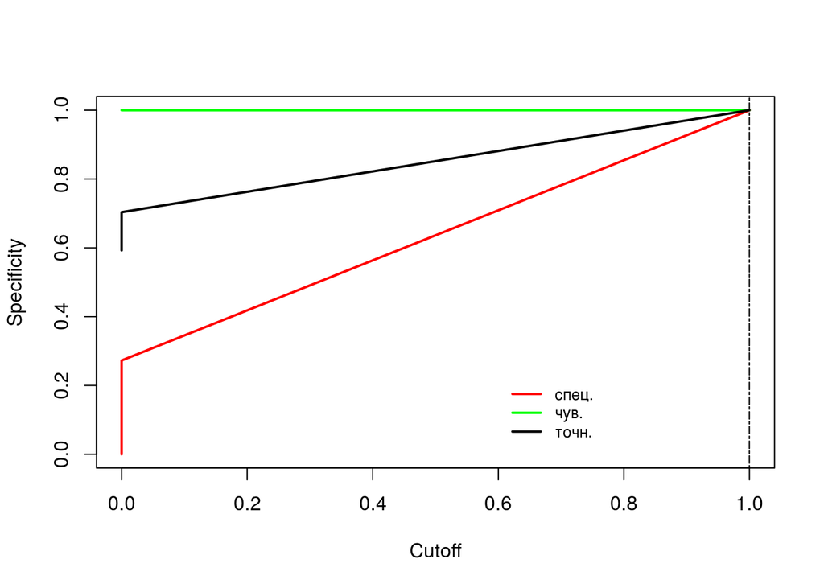

#### Аккуратность, чувствительность и специфичность выбранной модели

- Доля правильно классифицированных случаев PCCC = 0.9872269
- Чувствительность модели Se = 1
- Специфичность модели Sp = 1

### Определение 2 и 3 стадий стеатоза (SBs ~ SWS)

#### Модель: SBs ~ SWS

Предикторы статистически незначимы!

```
##
## Call:
## glm(formula = SBs.true ~ SWS, family = "binomial", data = df.S23)
##
## Deviance Residuals:
##     Min       1Q   Median       3Q      Max
## -2.2293  -0.8712   0.4172   0.4172   1.5183
##
## Coefficients:
##             Estimate Std. Error z value Pr(>|z|)
## (Intercept)   -16.57    2399.54  -0.007    0.994
## SWS2           18.96    2399.54   0.008    0.994
## SWS3           15.79    2399.54   0.007    0.995
##
## (Dispersion parameter for binomial family taken to be 1)
##
##     Null deviance: 44.236  on 31  degrees of freedom
## Residual deviance: 30.583  on 29  degrees of freedom
## AIC: 36.583
##
## Number of Fisher Scoring iterations: 15
```

#### ROC-кривая

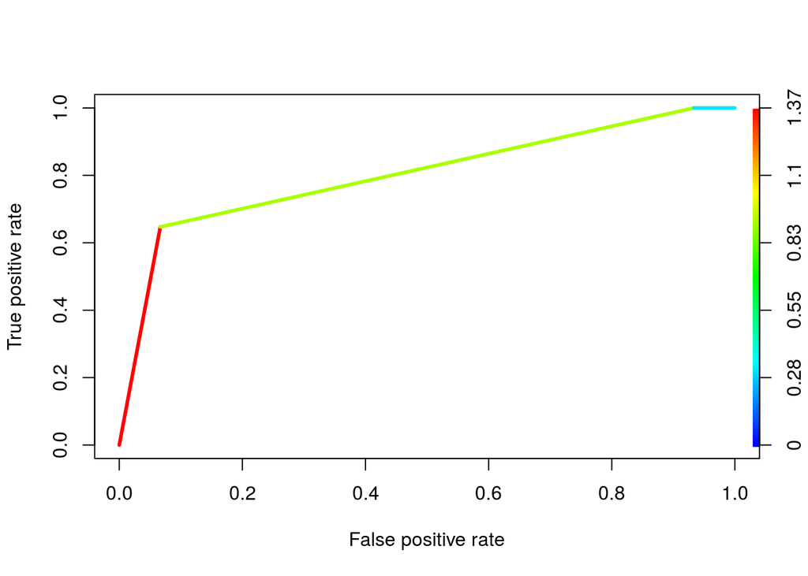

Площадь под кривой AUC=0.8019608

#### Кривые специфичности, чувствительности и аккуратности модели

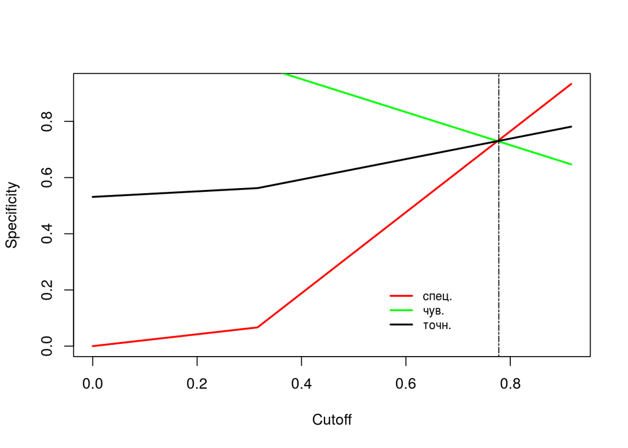

#### Аккуратность, чувствительность и специфичность выбранной модели

- Доля правильно классифицированных случаев PCCC = 0.7604872
- Чувствительность модели Se = 0.9333333
- Специфичность модели Sp = 0.6470588

## Ординальная логистическая регрессия

#### Модель1: FBs ~ FWF

Все предикторы статистически значимы (<<0.01)

```
## Call:
## polr(formula = FBs ~ FWF, data = df, Hess = TRUE)
##
## Coefficients:
##      Value Std. Error t value
## FWF1 2.215     0.5666   3.909
## FWF2 4.286     0.7391   5.799
## FWF3 6.615     1.0077   6.565
## FWF4 9.059     1.1603   7.807
##
## Intercepts:
##     Value  Std. Error t value
## 0|1 1.2083 0.3425     3.5277
## 1|2 3.2391 0.5192     6.2381
## 2|3 5.8422 0.7876     7.4178
## 3|4 7.8656 1.0166     7.7369
##
## Residual Deviance: 192.7508
## AIC: 208.7508
```

#### Модель2: FBs ~ Fscan

Все предикторы статистически значимы (<<0.01)

```
## Call:
## polr(formula = FBs ~ Fscan, data = df, Hess = TRUE)
##
## Coefficients:
##        Value Std. Error t value
## Fscan1 1.877     0.5710   3.287
## Fscan2 3.089     0.6706   4.607
## Fscan3 3.504     0.7066   4.960
## Fscan4 6.741     0.8517   7.915
##
## Intercepts:
##     Value  Std. Error t value
## 0|1 1.1475 0.3444     3.3315
## 1|2 2.8205 0.4622     6.1026
## 2|3 4.5401 0.5880     7.7220
## 3|4 5.9242 0.7318     8.0952
##
## Residual Deviance: 219.1116
## AIC: 235.1116
```

#### Сравнение Моделей 1 и 2

Согласно показателю AIC и отклонениям остатков (Residual Deviance) первая модель лучше. Тем не менее ANOVA показывает, что различия между моделями статистически незначимы.

```
## Likelihood ratio tests of ordinal regression models
##
## Response: FBs
##   Model Resid. df Resid. Dev   Test    Df  LR stat. Pr(Chi)
## 1   FWF       101   192.7508
## 2 Fscan       101   219.1116 1 vs 2     0 -26.36077       1
```

#### Модель3: SBs ~ SWS

Все предикторы статистически значимы (<<0.01)

```
## Call:
## polr(formula = SBs ~ SWS, data = df, Hess = TRUE)
##
## Coefficients:
##      Value Std. Error t value
## SWS1 3.006     0.6284   4.783
## SWS2 6.102     0.8888   6.865
## SWS3 6.208     0.8567   7.246
##
## Intercepts:
##     Value  Std. Error t value
## 0|1 1.9781 0.4354     4.5432
## 1|2 4.8809 0.7102     6.8729
## 2|3 7.7167 0.8622     8.9500
##
## Residual Deviance: 157.6654
## AIC: 169.6654
```